# 2. Tests of Independence

Michael Friendly

2026-06-07

OK, now we’re ready to do some analyses. This vignette focuses on relatively simple non-parametric tests and measures of association.

## CrossTable

For tabular displays, the `CrossTable()` function in the `gmodels` package produces cross-tabulations modeled after `PROC FREQ` in SAS or `CROSSTABS` in SPSS. It has a wealth of options for the quantities that can be shown in each cell.

Recall the GSS data used earlier.

```r
# Agresti (2002), table 3.11, p. 106
GSS <- data.frame(
  expand.grid(sex = c("female", "male"),
              party = c("dem", "indep", "rep")),
  count = c(279,165,73,47,225,191))

(GSStab <- xtabs(count ~ sex + party, data=GSS))
```

```
##         party
## sex      dem indep rep
##   female 279    73 225
##   male   165    47 191
```

Generate a cross-table showing cell frequency and the cell contribution to $\chi^2$.

```r
# 2-Way Cross Tabulation
library(gmodels)
CrossTable(GSStab, prop.t=FALSE, prop.r=FALSE, prop.c=FALSE)
```

```
##
##
##    Cell Contents
## |-------------------------|
## |                       N |
## | Chi-square contribution |
## |-------------------------|
##
##
## Total Observations in Table:  980
##
##
##              | party
##          sex |       dem |     indep |       rep | Row Total |
## -------------|-----------|-----------|-----------|-----------|
##       female |       279 |        73 |       225 |       577 |
##              |     1.183 |     0.078 |     1.622 |           |
## -------------|-----------|-----------|-----------|-----------|
##         male |       165 |        47 |       191 |       403 |
##              |     1.693 |     0.112 |     2.322 |           |
## -------------|-----------|-----------|-----------|-----------|
## Column Total |       444 |       120 |       416 |       980 |
## -------------|-----------|-----------|-----------|-----------|
##
##
```

There are options to report percentages (row, column, cell), specify decimal places, produce Chi-square, Fisher, and McNemar tests of independence, report expected and residual values (pearson, standardized, adjusted standardized), include missing values as valid, annotate with row and column titles, and format as SAS or SPSS style output! See `help(CrossTable)` for details.

## Chi-square test

For 2-way tables you can use `chisq.test()` to test independence of the row and column variable. By default, the $p$-value is calculated from the asymptotic chi-squared distribution of the test statistic. Optionally, the $p$-value can be derived via Monte Carlo simulation.

```r
(HairEye <- margin.table(HairEyeColor, c(1, 2)))
```

```
##        Eye
## Hair    Brown Blue Hazel Green
##   Black    68   20    15     5
##   Brown   119   84    54    29
##   Red      26   17    14    14
##   Blond     7   94    10    16
```

```r
chisq.test(HairEye)
```

```
##
##  Pearson's Chi-squared test
##
## data:  HairEye
## X-squared = 138.29, df = 9, p-value < 2.2e-16
```

```r
chisq.test(HairEye, simulate.p.value = TRUE)
```

```
##
##  Pearson's Chi-squared test with simulated p-value (based on 2000
##  replicates)
##
## data:  HairEye
## X-squared = 138.29, df = NA, p-value = 0.0004998
```

## Fisher Exact Test

`fisher.test(X)` provides an **exact test** of independence. `X` must be a two-way contingency table in table form. Another form, `fisher.test(X, Y)` takes two categorical vectors of the same length.  
For tables larger than $2 \times 2$ the method can be computationally intensive (or can fail) if the frequencies are not small.

```r
fisher.test(GSStab)
```

```
##
##  Fisher's Exact Test for Count Data
##
## data:  GSStab
## p-value = 0.03115
## alternative hypothesis: two.sided
```

Fisher’s test is meant for tables with small total sample size. It generates an error for the `HairEye` data with $n$=592 total frequency.

```r
fisher.test(HairEye)
```

```
## Error in `fisher.test()`:
## ! FEXACT error 6 (f5xact).  LDKEY=618 is too small for this problem: kval=238045028.
## Try increasing the size of the workspace.
```

## Mantel-Haenszel test and conditional association

Use the `mantelhaen.test(X)` function to perform a Cochran-Mantel-Haenszel $\chi^2$ chi test of the null hypothesis that two nominal variables are *conditionally independent*, $A \perp B \; | \; C$, in each stratum, assuming that there is no three-way interaction. `X` is a 3 dimensional contingency table, where the last dimension refers to the strata.

The `UCBAdmissions` serves as an example of a $2 \times 2 \times 6$ table, with `Dept` as the stratifying variable.

```r
# UC Berkeley Student Admissions
mantelhaen.test(UCBAdmissions)
```

```
##
##  Mantel-Haenszel chi-squared test with continuity correction
##
## data:  UCBAdmissions
## Mantel-Haenszel X-squared = 1.4269, df = 1, p-value = 0.2323
## alternative hypothesis: true common odds ratio is not equal to 1
## 95 percent confidence interval:
##  0.7719074 1.0603298
## sample estimates:
## common odds ratio
##         0.9046968
```

The results show no evidence for association between admission and gender when adjusted for department. However, we can easily see that the assumption of equal association across the strata (no 3-way association) is probably violated. For $2 \times 2 \times k$ tables, this can be examined from the odds ratios for each $2 \times 2$ table (`oddsratio()`), and tested by using `woolf_test()` in `vcd`.

```r
oddsratio(UCBAdmissions, log=FALSE)
```

```
##  odds ratios for Admit and Gender by Dept
##
##         A         B         C         D         E         F
## 0.3492120 0.8025007 1.1330596 0.9212838 1.2216312 0.8278727
```

```r
lor <- oddsratio(UCBAdmissions)  # capture log odds ratios
summary(lor)
```

```
##
## z test of coefficients:
##
##    Estimate Std. Error z value  Pr(>|z|)
## A -1.052076   0.262708 -4.0047 6.209e-05 ***
## B -0.220023   0.437593 -0.5028    0.6151
## C  0.124922   0.143942  0.8679    0.3855
## D -0.081987   0.150208 -0.5458    0.5852
## E  0.200187   0.200243  0.9997    0.3174
## F -0.188896   0.305164 -0.6190    0.5359
## ---
## Signif. codes:  0 '***' 0.001 '**' 0.01 '*' 0.05 '.' 0.1 ' ' 1
```

```r
woolf_test(UCBAdmissions)
```

```
##
## Woolf-test on Homogeneity of Odds Ratios (no 3-way association)
##
## Data:          UCBAdmissions
## OR variables:  Admit, Gender
## Strata:        Dept
##
## X-squared = 17.9017, df = 5, p-value = 0.003072
```

## Some plot methods

### Fourfold displays

We can visualize the odds ratios of Admission for each department with fourfold displays using `fourfold()`. The cell frequencies $n_{ij}$ of each $2 \times 2$ table are shown as a quarter circle whose radius is proportional to $\sqrt{n_{ij}}$, so that its area is proportional to the cell frequency.

```r
UCB <- aperm(UCBAdmissions, c(2, 1, 3))
dimnames(UCB)[[2]] <- c("Yes", "No")
names(dimnames(UCB)) <- c("Sex", "Admit?", "Department")
```

```r
col <- c("#99CCFF", "#6699CC", "#F9AFAF", "#6666A0", "#FF0000", "#000080")
fourfold(UCB, mfrow=c(2,3), color=col)
```

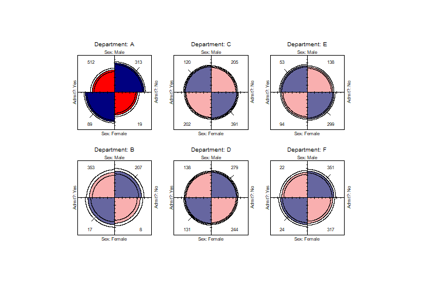

Fourfold display for the `UCBAdmissions` data. Where the odds ratio differs significantly from 1.0, the confidence bands do not overlap, and the circle quadrants are shaded more intensely.

```r
cotabplot(UCB, panel = cotab_fourfold)
```

[output not shown]

### Doubledecker plots

In this plot, the association between `Admit` and `Gender` is shown where the heights of the highlighted conditional probabilities do not align. The excess of females admitted in Dept A stands out here.

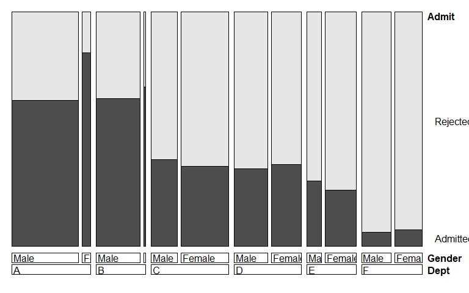

Doubledecker display for the `UCBAdmissions` data. The heights of the highlighted bars show the conditional probabilities of `Admit`, given `Dept` and `Gender`.

```r
doubledecker(Admit ~ Dept + Gender, data=UCBAdmissions[2:1,,])
```

### Odds ratio plots

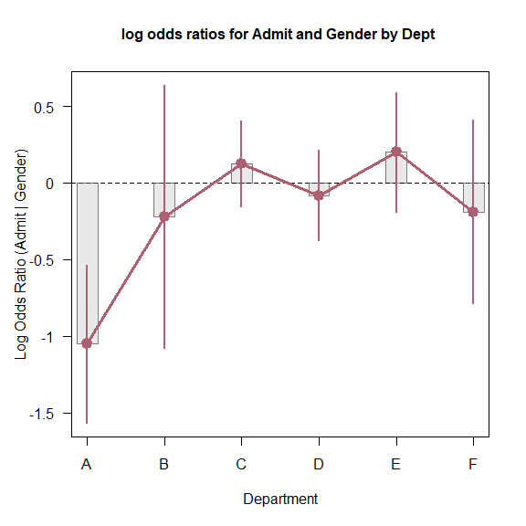

Log odds ratio plot for the `UCBAdmissions` data.

```r
plot(lor,
     xlab="Department",
     ylab="Log Odds Ratio (Admit | Gender)")
```

## Cochran-Mantel-Haenszel tests for ordinal factors

The standard $\chi^2$ tests for association in a two-way table treat both table factors as nominal (unordered) categories. When one or both factors of a two-way table are quantitative or ordinal, more powerful tests of association may be obtained by taking ordinality into account, using row and or column scores to test for linear trends or differences in row or column means.

More general versions of the CMH tests (Landis etal., 1978) (Landis et al. 1978) are provided by assigning numeric scores to the row and/or column variables. For example, with two ordinal factors (assumed to be equally spaced), assigning integer scores, `1:R` and `1:C` tests the linear $\times$ linear component of association. This is statistically equivalent to the Pearson correlation between the integer-scored table variables, with $\chi^2 = (n-1) r^2$, with only 1 $df$ rather than $(R-1)\times(C-1)$ for the test of general association.

When only one table variable is ordinal, these general CMH tests are analogous to an ANOVA, testing whether the row mean scores or column mean scores are equal, again consuming fewer $df$ than the test of general association.

The `CMHtest()` function in `vcdExtra` calculates these various CMH tests for two possibly ordered factors, optionally stratified other factor(s).

*Example*:

```r
JobSat
```

```
##         satisfaction
## income   VeryD LittleD ModerateS VeryS
##   < 15k      1       3        10     6
##   15-25k     2       3        10     7
##   25-40k     1       6        14    12
##   > 40k      0       1         9    11
```

Treating the `satisfaction` levels as equally spaced, but using midpoints of the `income` categories as row scores gives the following results:

```r
CMHtest(JobSat, rscores=c(7.5,20,32.5,60))
## Cochran-Mantel-Haenszel Statistics for income by satisfaction
##
##                  AltHypothesis  Chisq Df     Prob
## cor        Nonzero correlation 3.8075  1 0.051025
## rmeans  Row mean scores differ 4.4774  3 0.214318
## cmeans  Col mean scores differ 3.8404  3 0.279218
## general    General association 5.9034  9 0.749549
```

Note that with the relatively small cell frequencies, the test for general give no evidence for association. However, the the `cor` test for linear x linear association on 1 df is nearly significant. The `coin` package contains the functions `cmh_test()` and `lbl_test()` for CMH tests of general association and linear x linear association respectively.

## Measures of Association

There are a variety of statistical measures of *strength* of association for contingency tables— similar in spirit to $r$ or $r^2$ for continuous variables. With a large sample size, even a small degree of association can show a significant $\chi^2$, as in the example below for the `GSS` data.

The `assocstats()` function in `vcd` calculates the $\phi$ contingency coefficient, and Cramer’s V for an $r \times c$ table. The input must be in table form, a two-way $r \times c$ table. It won’t work with `GSS` in frequency form, but by now you should know how to convert.

```r
assocstats(GSStab)
```

```
##                     X^2 df P(> X^2)
## Likelihood Ratio 7.0026  2 0.030158
## Pearson          7.0095  2 0.030054
##
## Phi-Coefficient   : NA
## Contingency Coeff.: 0.084
## Cramer's V        : 0.085
```

For tables with ordinal variables, like `JobSat`, some people prefer the Goodman-Kruskal $\gamma$ statistic (Agresti 2002, 2.4.3) based on a comparison of concordant and discordant pairs of observations in the case-form equivalent of a two-way table.

```r
GKgamma(JobSat)
## gamma        : 0.221
## std. error   : 0.117
## CI           : -0.009 0.451
```

## Measures of Agreement

The `Kappa()` function in the `vcd` package calculates Cohen’s $\kappa$ and weighted $\kappa$ for a square two-way table with the same row and column categories (Cohen 1960). Normal-theory $z$-tests are obtained by dividing $\kappa$ by its asymptotic standard error (ASE). A `confint()` method for `Kappa` objects provides confidence intervals.

```r
data(SexualFun, package = "vcd")
(K <- Kappa(SexualFun))
```

```
##             value     ASE     z
## Unweighted 0.1293 0.06860 1.885
## Weighted   0.2374 0.07832 3.031
```

```r
confint(K)
```

```
##
## Kappa                 lwr       upr
##   Unweighted -0.005120399 0.2637809
##   Weighted    0.083883432 0.3908778
```

The Bangdiwala measures (returned by the function) represent the proportion of the shaded areas of the diagonal rectangles, using weights $w_1$ for exact agreement, and $w_2$ for partial agreement one step from the main diagonal.

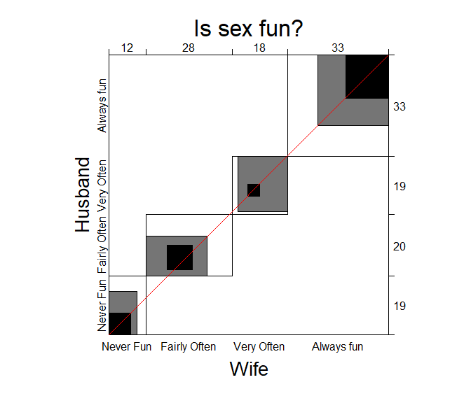

Agreement plot for the `SexualFun` data.

```r
agree <- agreementplot(SexualFun, main="Is sex fun?")
```

```r
unlist(agree)
```

```
##          Bangdiwala Bangdiwala_Weighted            weights1            weights2
##           0.1464624           0.4981723           1.0000000           0.8888889
```

In other examples, the agreement plot can help to show *sources* of disagreement. For example, when the shaded boxes are above or below the diagonal (red) line, a lack of exact agreement can be attributed in part to different frequency of use of categories by the two raters– lack of *marginal homogeneity*.

## Correspondence analysis

Here, we carry out a simple correspondence analysis of the `HairEye` data. The printed results show that nearly 99% of the association between hair color and eye color can be accounted for in 2 dimensions, of which the first dimension accounts for 90%.

```r
library(ca)
ca(HairEye)
```

```
##
##  Principal inertias (eigenvalues):
##            1        2        3
## Value      0.208773 0.022227 0.002598
## Percentage 89.37%   9.52%    1.11%
##
##
##  Rows:
##             Black     Brown       Red    Blond
## Mass     0.182432  0.483108  0.119932 0.214527
## ChiDist  0.551192  0.159461  0.354770 0.838397
## Inertia  0.055425  0.012284  0.015095 0.150793
## Dim. 1  -1.104277 -0.324463 -0.283473 1.828229
## Dim. 2   1.440917 -0.219111 -2.144015 0.466706
##
##
##  Columns:
##             Brown     Blue     Hazel     Green
## Mass     0.371622 0.363176  0.157095  0.108108
## ChiDist  0.500487 0.553684  0.288654  0.385727
## Inertia  0.093086 0.111337  0.013089  0.016085
## Dim. 1  -1.077128 1.198061 -0.465286  0.354011
## Dim. 2   0.592420 0.556419 -1.122783 -2.274122
```

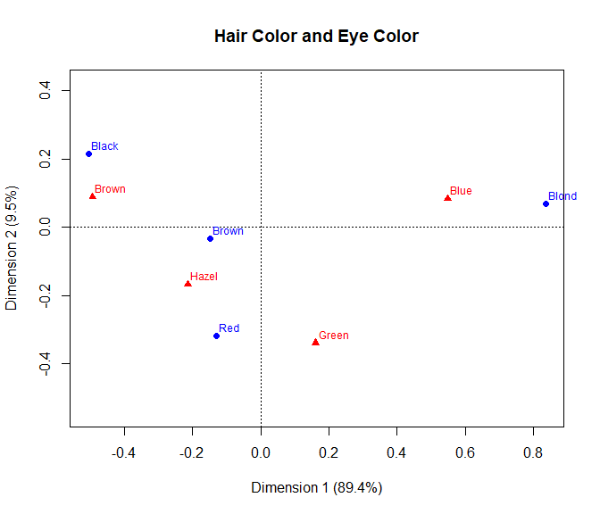

Correspondence analysis plot for the `HairEye` data

```r
plot(ca(HairEye), main="Hair Color and Eye Color")
```

## References

Agresti, Alan. 2002. *Categorical Data Analysis*. 2nd ed. John Wiley & Sons.

Bangdiwala, Shrikant I. 1987. “Using SAS Software Graphical Procedures for the Observer Agreement Chart.” *Proceedings of the SAS User’s Group International Conference* 12: 1083–88.

Cohen, J. 1960. “A Coefficient of Agreement for Nominal Scales.” *Educational and Psychological Measurement* 20: 37–46.

Landis, R. J., E. R. Heyman, and G. G. Koch. 1978. “Average Partial Association in Three-Way Contingency Tables: A Review and Discussion of Alternative Tests,” *International Statistical Review* 46: 237–54.